# Practical Machine Learning - Activity Quality Prediction

## Introduction

Using devices such as Jawbone Up, Nike FuelBand, and Fitbit it is now possible to collect a large amount of data about personal activity relatively inexpensively. These type of devices are part of the quantified self movement - a group of enthusiasts who take measurements about themselves regularly to improve their health, to find patterns in their behavior. One thing that people regularly do is quantify how much of a particular activity they do, but they rarely quantify how well they do it. In this project, the goal is to use data from accelerometers on the belt, forearm, arm, and dumbell of 6 participants. They were asked to perform barbell lifts correctly and incorrectly in 5 different ways.

## Methods

### Getting data

The data for this project come from this source: http://groupware.les.inf.puc-rio.br/har. Six young health participants were asked to perform one set of 10 repetitions of the Unilateral Dumbbell Biceps Curl in five different fashions: exactly according to the specification (Class A), throwing the elbows to the front (Class B), lifting the dumbbell only halfway (Class C), lowering the dumbbell only halfway (Class D) and throwing the hips to the front (Class E). The data were recorded from accelerometers. We downloaded pml-training.csv and pml-testing.csv datasets on 26 Jan 2015.

```r
set.seed(111)
library(caret, quietly=T)
setwd("C:\\Users\\fupc\\Desktop\\c8\\proj")
data <- read.csv("pml-training.csv", na.strings="NA", header=T)
data <- data[sample(nrow(data)),]
inTrain <- createDataPartition(data$X, p = 0.7)[[1]]
train <- data[inTrain,]
valid <- data[-inTrain,]
test <- read.csv("pml-testing.csv", na.strings="NA", header=T)
```

### Cleaning data

This step is to remove columns that are mostly NAs.

```r
idx2remove <- function(df){
  idx <- c()
  for (i in 1:dim(df)[2]){
    if (sum(is.na(df[,i]))/dim(df)[1] > 0.1) idx <- c(idx, i)
  }
  return(idx)
}
col.to.remove <- unique(c(idx2remove(train), idx2remove(valid), idx2remove(test)))

trainC <- train$classe
train <- train[,-c(col.to.remove)]

validC <- valid$classe
valid <- valid[,-c(col.to.remove)]

testC <- test$problem_id
test <- test[,-c(col.to.remove)]
train <- train[,sapply(train, is.numeric)]
valid <- valid[,sapply(valid, is.numeric)]
test <- test[,sapply(test, is.numeric)]
```

This step is to remove columns with high correlation (correlation over 0.9).

```r
num.idx <- which(sapply(train, class) == "numeric")
descrCorr <- abs(cor(train[,num.idx]))
highCorr <- findCorrelation(descrCorr, 0.9)
highCorrCol <- dimnames(descrCorr[, highCorr])[[2]]
train <- train[, !names(train) %in% c(highCorrCol, "X", "cvtd_timestamp", "raw_timestamp_part_1",  "raw_timestamp_part_2",  "num_window", "classe")]
valid <-valid[, !names(valid) %in% c(highCorrCol, "X", "cvtd_timestamp", "raw_timestamp_part_1",  "raw_timestamp_part_2",   "num_window", "classe")]
test <- test[, !names(test) %in% c(highCorrCol, "X", "cvtd_timestamp", "raw_timestamp_part_1",  "raw_timestamp_part_2", "num_window", "problem_id")]
train <- sapply(train, as.numeric)
valid <- sapply(valid, as.numeric)
test <- as.matrix(sapply(test, as.numeric))
```

### Statistical Modeling

As input data is high-dimensional, Random Forest from the **randomForest** package is chosen to building a predictive model. We built the model for the outcome variable *classe* using 49 predictive variables.

```r
library(randomForest, quietly=T)
fitRF <- randomForest(x=train, y=trainC, importance=T, ntree=317)
fitRF
```

```
##
## Call:
##  randomForest(x = train, y = trainC, ntree = 317, importance = T)
##                Type of random forest: classification
##                      Number of trees: 317
## No. of variables tried at each split: 7
##
##         OOB estimate of  error rate: 0.52%
## Confusion matrix:
##      A    B    C    D    E  class.error
## A 3900    2    0    0    0 0.0005125577
## B   12 2628    6    0    0 0.0068027211
## C    0   17 2376    6    0 0.0095873281
## D    0    0   21 2253    2 0.0101054482
## E    0    0    1    4 2510 0.0019880716
```

Here we can see 5 the most important variables

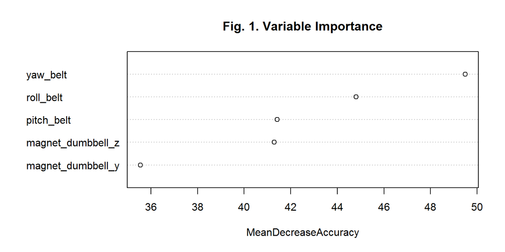

```r
varImpPlot(fitRF, n.var=5, type=1, main="Fig. 1. Variable Importance")
```

With number of trees of 317 the Random Forest was successfully trained and the estimated OOB error rate (in sample error) for the training set was 0.52%. We don’t need to do cross-validation as random forest uses bootstrap samples from the train set.

### Results

On the fig. 1 we can see the most important variables for the predicting model: yaw_belt, roll_belt, pitch_belt.

Let’s plot the three variables. On the figures 2-4 we can see the relationship between those variables. We color grouped the points based on the 5 levels of activities quality. The figures show rather complicated patterns which cannot be linearly separated, thus, we used random forest.

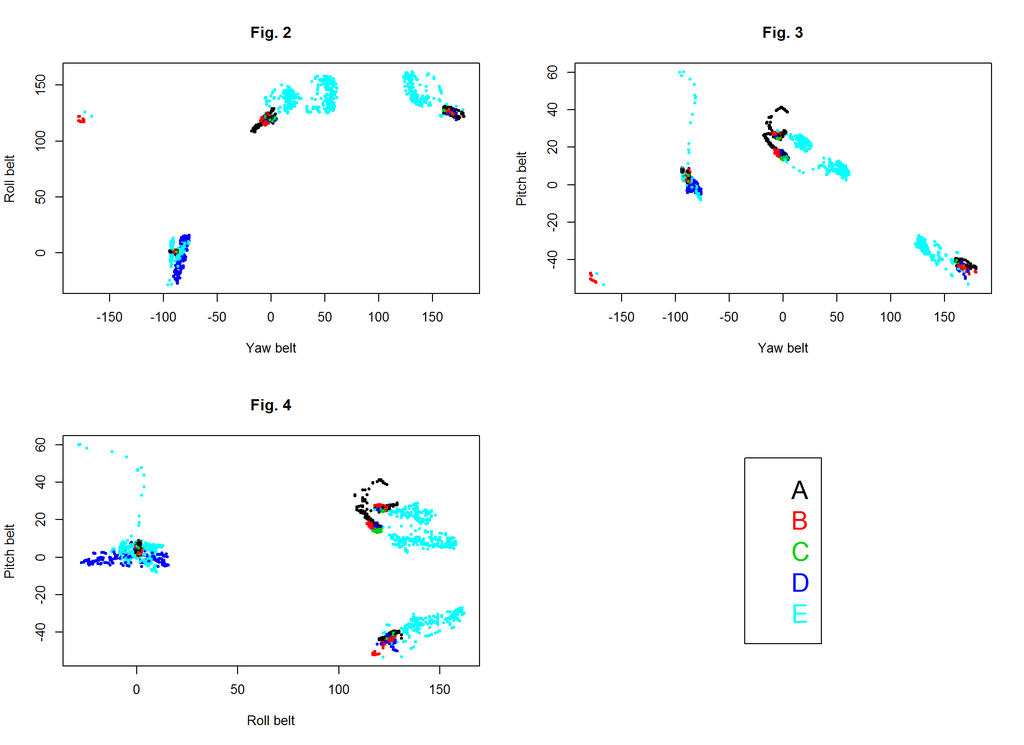

```r
par(mfrow=c(2,2))
valid <- data.frame(valid)
plot(valid$yaw_belt, valid$roll_belt,
     xlab="Yaw belt",
     ylab="Roll belt",
     main="Fig. 2",col=as.numeric(validC), pch=19, cex=.5)

plot(valid$yaw_belt,valid$pitch_belt,
     xlab="Yaw belt",
     ylab="Pitch belt",
     main="Fig. 3",col=as.numeric(validC), pch=19, cex=.5)

plot(valid$roll_belt,valid$pitch_belt,
     xlab="Roll belt",
     ylab="Pitch belt",
     main="Fig. 4",col=as.numeric(validC), pch=19, cex=.5)
plot.new()
legend("center", legend=levels(validC), cex=2, text.col=seq_along(levels(validC)))
```

We tested out model on validation set and observed a confusion matrix for the validation set.

```r
predRF <- predict(fitRF, valid)
confusionMatrix(predRF, validC)
```

```
## Confusion Matrix and Statistics
##
##           Reference
## Prediction    A    B    C    D    E
##          A 1678    8    0    0    0
##          B    0 1142    3    0    0
##          C    0    1 1019    7    1
##          D    0    0    1  933    1
##          E    0    0    0    0 1090
##
## Overall Statistics
##
##                Accuracy : 0.9963
##                  95% CI : (0.9943, 0.9977)
##     No Information Rate : 0.2852
##     P-Value [Acc > NIR] : < 2.2e-16
##
##                   Kappa : 0.9953
##  Mcnemar's Test P-Value : NA
##
## Statistics by Class:
##
##                      Class: A Class: B Class: C Class: D Class: E
## Sensitivity            1.0000   0.9922   0.9961   0.9926   0.9982
## Specificity            0.9981   0.9994   0.9981   0.9996   1.0000
## Pos Pred Value         0.9953   0.9974   0.9912   0.9979   1.0000
## Neg Pred Value         1.0000   0.9981   0.9992   0.9986   0.9996
## Prevalence             0.2852   0.1956   0.1739   0.1598   0.1856
## Detection Rate         0.2852   0.1941   0.1732   0.1586   0.1852
## Detection Prevalence   0.2865   0.1946   0.1747   0.1589   0.1852
## Balanced Accuracy      0.9990   0.9958   0.9971   0.9961   0.9991
```

Out of sample error is about 0.37%. Finally we tested our model on the 20 test cases available in the test data. We got 100% prediction accuracy.

```r
predRFT <- predict(fitRF, test)
answer <- as.character(predRFT)
pml_write_files <- function(x){
  n <- length(x)
  for(i in 1:n){
    filename <- paste0("problem_id_",i,".txt")
    write.table(x[i],file <- filename,quote=FALSE,row.names=FALSE,col.names=FALSE)
  }
}
pml_write_files(answer)
```

### Conclusions

In this paper we proposed a predictive model based on Random Forest. This model provides high accuracy in identifying of activity quality.